# MAST 6252 - Homework 1

Group 9–Kai P., Phuong T., Gideon S., and Xiaofei X.

October 22, 2016

- Before answering the questions, we need to load the following packages: ggplot2, tidyr and xtable.

# Question 1

**Defining the functions**

- We first define the structure of the **log likelihood function** by using the equation below.

$$LL=\sum_{i=1}^{N} y_{i} log P(t_{i}|a,b) + (1 - y_{i})logS(t_{i}|a,b)$$

- Secondly, by applying the Law of Total probability, we can derive the churn probability and survival probability and then apply to the log likelihood function:

**churn function:**

$$log(Pr(T=t|a,b)) = \log B(a+1, b+t-1) - \log B(a, b)$$

**survival function:**

$$Pr(T>t|a,b) = \frac{B(a, b+t)}{B(a,b)}$$

$$\log(Pr(T>t|a,b)) = \log B(a, b+t) - \log B(a, b)$$

```r
log_P <- function(t,a, b){lbeta(a+1, b+t-1) - lbeta(a,b)}
log_S <- function(t,a, b){lbeta(a, b+t) - lbeta(a,b)}
LL <- function(pars, N, S){
    a <- exp(pars[1])
    b <- exp(pars[2])
    Tobs <- length(N)
    t <- 1:Tobs
    LL_P <- sum(N * log_P(t,a, b))
    LL_S <- S * log_S(Tobs,a, b)
    LL_all <- LL_P + LL_S
    return(-LL_all)
}
```

**Computing probabilities and likelihood**

- We then input data into the above functions to estimate the parameters a and b from the maximum likelihood method.

```r
N0 <- 2132
Tobs <- 8
full <- data_frame(t=1:8,
                   S=c(1406,1069,894,765,656,578,525,482))
full <- mutate(full, N=c(N0-S[1], -diff(S)))
pars.start <- c(0,0)
res <- optim(pars.start, fn=LL,
             N=full$N[1:Tobs],
             S=full$S[Tobs])
LL_mle <- -res$value
pars_mle <-res$par
a <- exp(pars_mle[1])
b <- exp(pars_mle[2])
```

The results of MLE of the model parameters (a and b) and the log likelihood (LL) at the MLE is as follows:

- a = .791
- b = 1.54
- LL = -3869

```r
cat("LL = ", LL_mle,"a=",a,"b=",b,"\n")
```

```
## LL =  -3869 a= 0.791 b= 1.54
```

Below is the table that offers face-validity to our model

```r
colnames(full) <- c("t", "Active", "Churn")
P_exp <- exp(log_P(1:8,a, b))
N_exp <- 2132 * P_exp
full <- mutate(full, Churn_Predicted=N_exp,
               Active_Predicted= 2132 - cumsum(N_exp))
dat <- gather(full, var, count, -t)
full
```

```
## # A tibble: 8 × 5
##       t Active Churn Churn_Predicted Active_Predicted
##   <int>  <dbl> <dbl>           <dbl>            <dbl>
## 1     1   1406   726           723.0             1409
## 2     2   1069   337           334.5             1074
## 3     3    894   175           196.2              878
## 4     4    765   129           130.3              748
## 5     5    656   109            93.5              654
## 6     6    578    78            70.6              584
## 7     7    525    53            55.4              528
## 8     8    482    43            44.8              484
```

**Plotting the data**

- The first plot - betaplot - demonstrates relationship between theta and parameters a & b. Because we get an a<1 and b>1, we can get an “L” shaped distribution.

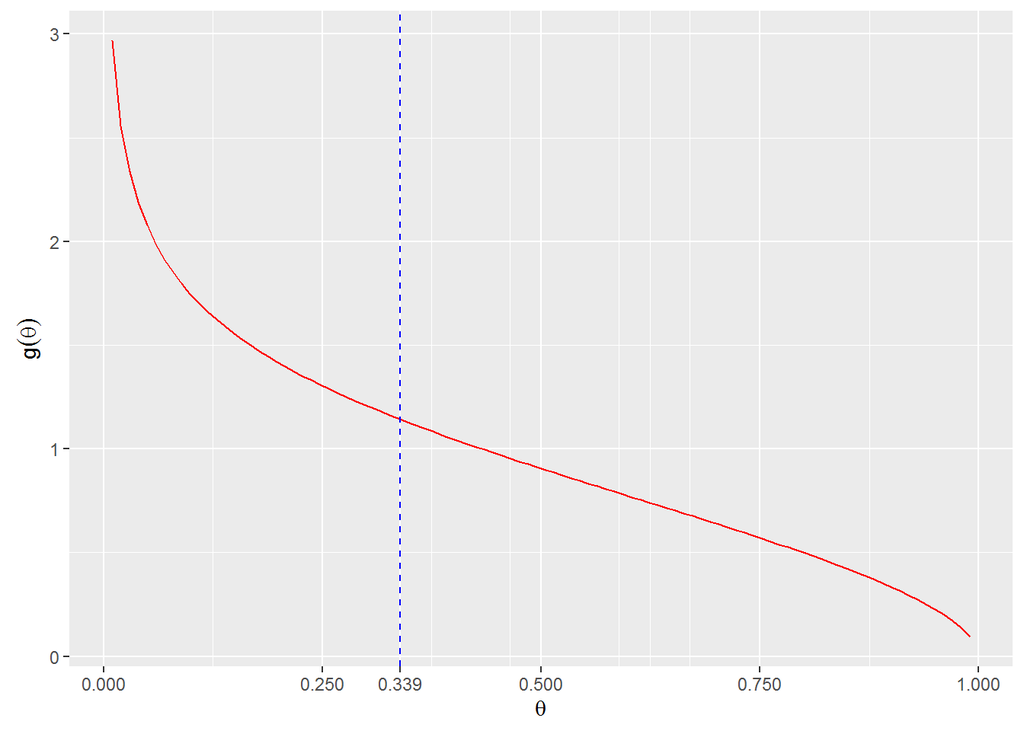

```r
betaplot <- data_frame(theta=seq(.01,.99,length=100),
                        g=dbeta(theta,a,b)) %>%
      ggplot(aes(x=theta,y=g))  %>%
      + geom_line(color="red")  %>%
      + geom_vline(xintercept = a/(a+b), color="blue",linetype=2,size=.5) %>%
      + scale_y_continuous(expression({g}(theta))) %>%
      + scale_x_continuous(expression(theta),
                      breaks=c(seq(0,1, by=.25), a/(a+b)),
                    labels=format(c(seq(0,1,by=.25),a/(a+b)),digits=3))
betaplot
```

- The second plot illustrates the preciseness of the predicted active model with the observed active model.

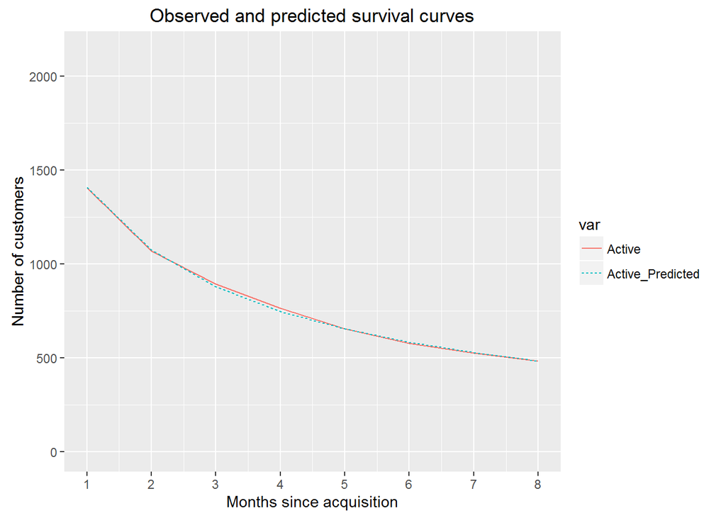

```r
plot_Obs_V_Pred <- filter(dat, var %in% c("Active","Active_Predicted")) %>%
  ggplot(aes(x=t, y=count, color=var, linetype=var)) %>%
  + ggtitle("Observed and predicted survival curves") %>%
  + geom_line() %>%
  + scale_x_continuous("Months since acquisition",
                       breaks = 1:max(dat$t), labels=1:max(dat$t)) %>%
  + scale_y_continuous("Number of customers",
                       limits=c(0,2132))
plot_Obs_V_Pred
```

# Question 2

For the questions (a-e) below, we consider a randomly-chosen memeber of the population who was newly acquired in January

The first two questions utilize the log liklihood churn function, as defined by :
$$log(Pr(T=t|a,b)) = \log B(a+1, b+t-1) - \log B(a, b)$$

**a.** The expected probability of a customer will cancel after one month. We input t=1

- Answer = .339

```r
expected1 <- exp(log_P(1,a,b))
expected1
```

```
## [1] 0.339
```

**b.** The expected probability of a customer will cancel service after two months. We input t=2

- Answer = .157

```r
expected2 <- exp(log_P(2,a,b))
expected2
```

```
## [1] 0.157
```

For the next 3 questions, we use the Posterior Survival Function to solve the problems. The posterior survival function is as follows:

$$\log(S(t|T>n-1,a,b))=\log B(a, b+n-1+t) - \log B(a,b+n-1)$$

**c.** The expected probability that the customer will renew for March. We input n = 2 and t = 1

- Answer = .763

```r
log_S_update <- function(t,n,a, b){lbeta(a, b+t-1+n) - lbeta(a,b+n-1)}
expected3 <- exp(log_S_update(1,2,a,b))
expected3
```

```
## [1] 0.763
```

**d.** The expected renewal probability for a customer who remained active through August. We input n = 8 and t = 1

- Answer = .915

```r
expected4 <- exp(log_S_update(1,8,a,b))
expected4
```

```
## [1] 0.915
```

**e.** The expected number of members of the cohort who remained active through the end of the year.

```r
expected_end <- exp(log_S_update(3,9,a,b))*full$Active[8]
expected_end
```

```
## [1] 387
```

# Question 3

To answer this questions, we calculate the retention rates for the respective cohorts based on the **Beta-Geometric model.**

$$r(t|a,b)=\frac{b+t-1}{a+b+t-1}$$

**a.** Completed table of number of members of each cohort (using predicted counts from the BG Model)

```r
table_a <- data_frame(Month=c("September","October","November","December","January","February","March","April","May","June","July","August"))
table_a <- mutate(table_a,Sept.=c(N0,N0*exp(log_S(1:11,a,b))),
                          Oct.=c(0,N0,N0*exp(log_S(1:10,a,b))),
                          Nov.=c(0,0,N0,N0*exp(log_S(1:9,a,b))),
                          Dec.=c(0,0,0,N0,N0*exp(log_S(1:8,a,b))),
                          Total=Sept.+Oct.+Nov.+Dec.)
table_a
```

```
## # A tibble: 12 × 6
##        Month Sept.  Oct.  Nov.  Dec. Total
##        <chr> <dbl> <dbl> <dbl> <dbl> <dbl>
## 1  September  2132     0     0     0  2132
## 2    October  1409  2132     0     0  3541
## 3   November  1074  1409  2132     0  4615
## 4   December   878  1074  1409  2132  5494
## 5    January   748   878  1074  1409  4110
## 6   February   654   748   878  1074  3355
## 7      March   584   654   748   878  2864
## 8      April   528   584   654   748  2515
## 9        May   484   528   584   654  2250
## 10      June   447   484   528   584  2042
## 11      July   415   447   484   528  1874
## 12    August   389   415   447   484  1734
```

**b.** Examination of retention rates from January to August for each cohort * Retention rate table

```r
retention <- data_frame(t=c(1:7),
                        retention_Sept = table_a$Sept.[6:12]/table_a$Sept.[5:11],
                        retention_Oct = table_a$Oct.[6:12]/table_a$Oct.[5:11],
                        retention_Nov = table_a$Nov.[6:12]/table_a$Nov.[5:11],
                        retention_Dec = table_a$Dec.[6:12]/table_a$Dec.[5:11],
                        retention_aggre = table_a$Total[6:12]/table_a$Total[5:11])
retention
```

```
## # A tibble: 7 × 6
##       t retention_Sept retention_Oct retention_Nov retention_Dec
##   <int>          <dbl>         <dbl>         <dbl>         <dbl>
## 1     1          0.875         0.852         0.817         0.763
## 2     2          0.892         0.875         0.852         0.817
## 3     3          0.905         0.892         0.875         0.852
## 4     4          0.915         0.905         0.892         0.875
## 5     5          0.923         0.915         0.905         0.892
## 6     6          0.930         0.923         0.915         0.905
## 7     7          0.936         0.930         0.923         0.915
## # ... with 1 more variables: retention_aggre <dbl>
```

**Retention rate plot**

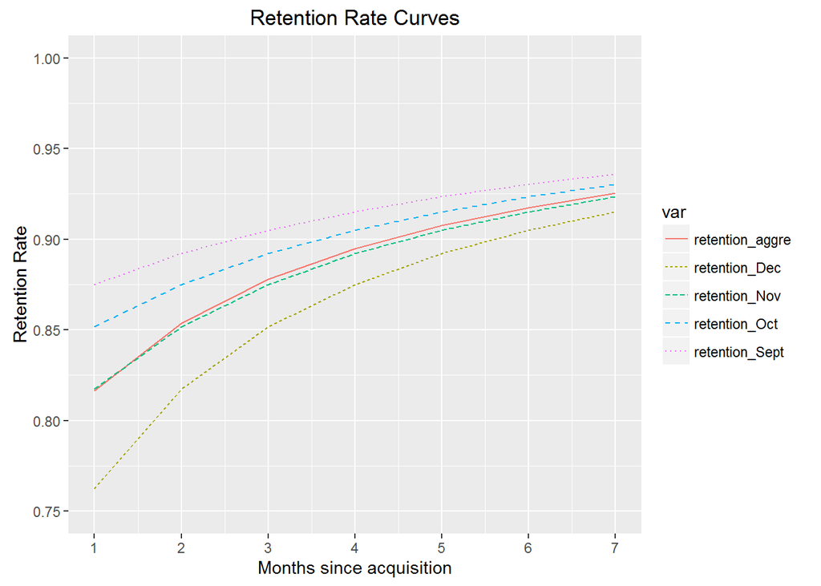

```r
dat2 <- gather(retention, var, count, -t)
plot_RR <- ggplot(dat2, aes(x=t, y=count, color=var, linetype=var)) %>%
  + ggtitle("Retention Rate Curves") %>%
  + geom_line() %>%
  + scale_x_continuous("Months since acquisition",
                       breaks = 1:max(dat2$t), labels=1:max(dat2$t)) %>%
  + scale_y_continuous("Retention Rate",
                       limits=c(0.75,1))
plot_RR
```

**Explanation of the patterns**

- The timing of an entering cohort makes a difference. Having different times affects their respective retention rates. The earlier a cohort was acquired (e.g. Sept. cohort), the flatter and higher its retention curve is. Moreover, if the curve is flat, there is more homogeneity in the thetas. Additionally, retention rates are only calculated after January, before which many customers have already churned for cohorts that were acquired prior. Individuals who are more likely to churn, tend to churn at the beginning. In January, the Sept. cohort would contain a larger proportion of loyal (alive) customers, while the newly-acquired Dec. cohort would contain a smaller proportion of loyal customers due to its relative starting date.
- Lastly, with regards to the aggregated customer base, one would assume that the curve land fairly inbetween Oct. and Nov. cohorts, but in fact, it is closer to Nov.’s. The reason for this is becuase it is a weighted average of the retention curves. In general, when examining retention curves, best practices are to look at individual cohorts rather than relying solely on the aggregate curve.